# Exploratory Data Analysis

## Q2

Based on past sales data and trends, predict which Genre of game is likely to have the highest Global_Sales in the next year

```r
# Filter only rows with valid Year and Global_Sales
filtered_data <- fir_dataset %>%
  filter(!is.na(Year), !is.na(Global_Sales))

# Group by Year and Genre and sum the Global_Sales
grouped_data <- filtered_data %>%
  group_by(Year, Genre) %>%
  summarise(Total_Global_Sales = sum(Global_Sales), .groups = "drop")

# Split the data by Genre
split_data <- split(grouped_data, grouped_data$Genre)

# Function to forecast sales
forecast_sales <- function(data) {
  model <- auto.arima(data$Total_Global_Sales, seasonal = TRUE)
  forecast(model, h=1)$mean
}

# Apply the function to each Genre
forecasts <- lapply(split_data, forecast_sales)

# Extract the genre with the highest forecasted sales
predicted_genre <- names(which.max(unlist(forecasts)))

print(predicted_genre)
```

```
## [1] "Action"
```

## Q3

What platform has the highest average Global Sales, and which one has the lowest? And plot a histogram for all platforms

```r
# Group by Platform and calculate the average Global Sales
platform_sales <- fir_dataset %>%
  group_by(Platform) %>%
  summarise(Avg_Global_Sales = mean(Global_Sales, na.rm = TRUE)) %>%
  arrange(Avg_Global_Sales)

# Display which platform has the highest and lowest average Global Sales
highest_platform <- tail(platform_sales, 1)
lowest_platform <- head(platform_sales, 1)

print(highest_platform)
```

```
## # A tibble: 1 × 2
##   Platform Avg_Global_Sales
##   <chr>               <dbl>
## 1 GB                   2.61
```

```r
print(lowest_platform)
```

```
## # A tibble: 1 × 2
##   Platform Avg_Global_Sales
##   <chr>               <dbl>
## 1 PCFX                 0.03
```

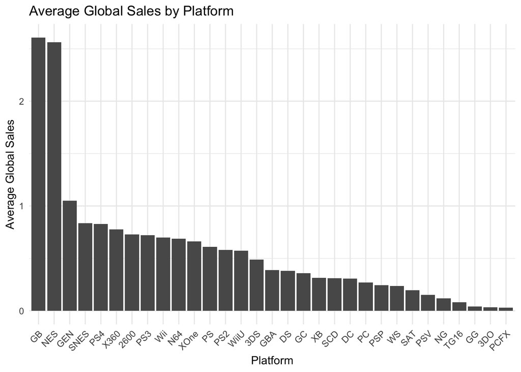

```r
# Plot a histogram for all platforms
ggplot(platform_sales, aes(x = reorder(Platform, -Avg_Global_Sales), y = Avg_Global_Sales)) +
  geom_bar(stat = "identity") +
  labs(title = "Average Global Sales by Platform",
       x = "Platform",
       y = "Average Global Sales") +
  theme_minimal() +
  theme(axis.text.x = element_text(angle = 45, hjust = 1))
```

## Q4

We can roughly categorize gaming platforms into 4 Sony Nintendo Microsoft Others What are the sales of each of these four？

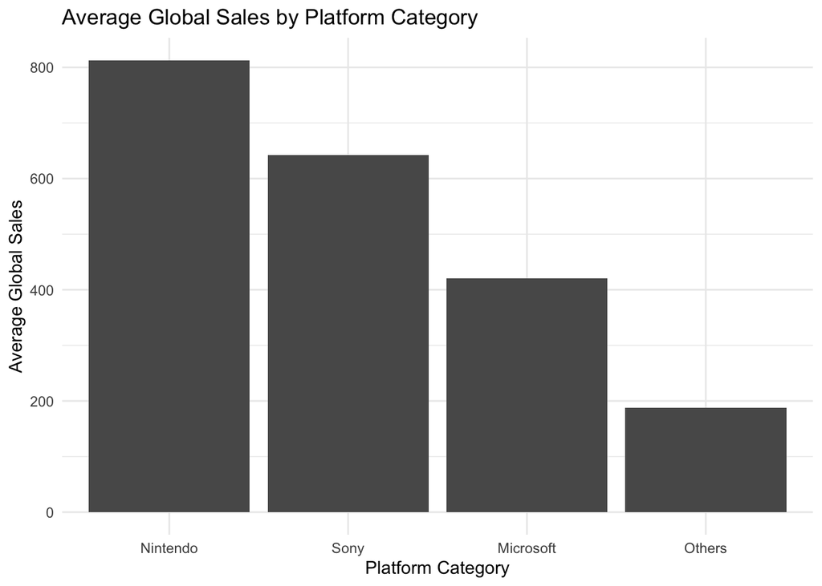

```r
library(tidyverse)


platform_categories <- list(
  Sony = c("PS4", "PS3", "PS2", "PSP", "PSV"),
  Microsoft = c("X360", "XOne", "XB"),
  Nintendo = c("GB", "NES", "SNES", "Wii", "N64", "WiiU", "3DS", "GBA", "DS", "GC"),
  Others = c("GEN", "2600", "DC", "PC", "WS", "SAT", "TG16", "NG", "GG", "3DO", "PCFX")
)


final_data$Platform_Category <- case_when(
  final_data$Platform %in% platform_categories$Sony ~ "Sony",
  final_data$Platform %in% platform_categories$Microsoft ~ "Microsoft",
  final_data$Platform %in% platform_categories$Nintendo ~ "Nintendo",
  TRUE ~ "Others"
)
final_data$Platform_Category <- case_when(
  final_data$Platform %in% platform_categories$Sony ~ "Sony",
  final_data$Platform %in% platform_categories$Microsoft ~ "Microsoft",
  final_data$Platform %in% platform_categories$Nintendo ~ "Nintendo",
  TRUE ~ "Others"
)

average_sales_df <- final_data %>%
  group_by(Platform_Category) %>%
  summarise(Average_Global_Sales = sum(Global_Sales, na.rm = TRUE)) %>%
  arrange(desc(Average_Global_Sales))

ggplot(average_sales_df, aes(x = reorder(Platform_Category, -Average_Global_Sales), y = Average_Global_Sales)) +
  geom_bar(stat = "identity") +
  labs(title = "Average Global Sales by Platform Category",
       x = "Platform Category",
       y = "Average Global Sales") +
  theme_minimal()
```

## Q5

Do the regions have their own favorite genres and types of consoles?

```r
popular_genre_by_region <- fir_dataset %>%
  group_by(Genre) %>%
  summarise(
    NA_Sales = sum(NA_Sales, na.rm = TRUE),
    EU_Sales = sum(EU_Sales, na.rm = TRUE),
    JP_Sales = sum(JP_Sales, na.rm = TRUE),
    Other_Sales = sum(Other_Sales, na.rm = TRUE)
  ) %>%
  gather(Region, Sales, -Genre) %>%
  group_by(Region) %>%
  top_n(1, Sales) %>%
  ungroup() %>%
  select(Region, Genre)


popular_genre_by_region %>% print()
```

```
## # A tibble: 4 × 2
##   Region      Genre
##   <chr>       <chr>
## 1 NA_Sales    Action
## 2 EU_Sales    Action
## 3 JP_Sales    Role-Playing
## 4 Other_Sales Action
```

```r
popular_platform_by_region <- fir_dataset %>%
  group_by(Platform) %>%
  summarise(
    NA_Sales = sum(NA_Sales, na.rm = TRUE),
    EU_Sales = sum(EU_Sales, na.rm = TRUE),
    JP_Sales = sum(JP_Sales, na.rm = TRUE),
    Other_Sales = sum(Other_Sales, na.rm = TRUE)
  ) %>%
  gather(Region, Sales, -Platform) %>%
  group_by(Region) %>%
  top_n(1, Sales) %>%
  ungroup() %>%
  select(Region, Platform)


popular_platform_by_region %>% print()
```

```
## # A tibble: 4 × 2
##   Region      Platform
##   <chr>       <chr>
## 1 NA_Sales    X360
## 2 EU_Sales    PS3
## 3 JP_Sales    DS
## 4 Other_Sales PS2
```

## Q6

Do the four manufacturers specialize in the types of games they release (judged by the total number of types of games released by the manufacturer) and also output the types of games that sell the most in the top 10 games for each plate

```r
selected_publishers <- c("Nintendo", "Microsoft",  "Sony")


popular_genre_by_publisher <- final_data %>%
  filter(Platform_Category %in% selected_publishers) %>%
  group_by(Platform_Category, Genre) %>%
  summarise(Count = n()) %>%
  arrange(Platform_Category, desc(Count)) %>%
  group_by(Platform_Category) %>%
  slice_head(n = 1) %>%
  ungroup()
popular_genre_by_publisher %>% print()
```

```
## # A tibble: 3 × 3
##   Platform_Category Genre  Count
##   <chr>             <chr>  <int>
## 1 Microsoft         Action    72
## 2 Nintendo          Action    72
## 3 Sony              Action   116
```

```r
top_10_games_by_platform <- final_data %>%
  group_by(Platform_Category) %>%
  top_n(10, Global_Sales) %>%
  ungroup()


popular_genre_in_top_10_by_platform <- top_10_games_by_platform %>%
  filter(Platform_Category %in% selected_publishers) %>%
  group_by(Platform_Category, Genre) %>%
  summarise(Count = n()) %>%
  arrange(Platform_Category, desc(Count)) %>%
  group_by(Platform_Category) %>%
  slice_head(n = 1) %>%
  ungroup()
popular_genre_in_top_10_by_platform %>% print()
```

```
## # A tibble: 3 × 3
##   Platform_Category Genre    Count
##   <chr>             <chr>    <int>
## 1 Microsoft         Shooter      8
## 2 Nintendo          Platform     5
## 3 Sony              Action       6
```

#Follow-up Questions

## New Questions Based Off Initial Investigation

1.Compare with the 3 main company, how to predict their Sales number in different Area. 2.How to predict global sales for a newly released game？ 3.Focus on the Nintendo what is the sales change between the games from 1980s to 2000 and 2000 to 2010 and 2010 for now and how to predict in next 5 years sales ? 4.How to predict the Rating based on the dataset?

We will focus on the Q2 and Q4

```r
 Q2data <- final_data %>%
  mutate(Year = if_else(Year == "N/A", NA_character_, Year)) %>%
  mutate(Year = if_else(grepl("^\\d+$", Year), as.numeric(Year), NA_real_))%>%
  na.omit(final_data) %>%
  rowwise() %>%
  mutate(Sequel = ifelse(str_detect(Name, "[:0-9IXV]"), 1, 0))%>%
  mutate(NoR = ifelse(grepl("K", NoR),
                      as.numeric(sub("K", "", NoR)) * 1000,
                      as.numeric(NoR)))%>%
  mutate(Plays = ifelse(grepl("K", NoR),
                      as.numeric(sub("K", "", NoR)) * 1000,
                      as.numeric(NoR)))
```

## Multiple linear Regression

```r
set.seed(123)
splitIndex <- createDataPartition(Q2data$Global_Sales, p = .75, list = FALSE)
train_data <- Q2data[splitIndex, ]
test_data  <- Q2data[-splitIndex, ]
```

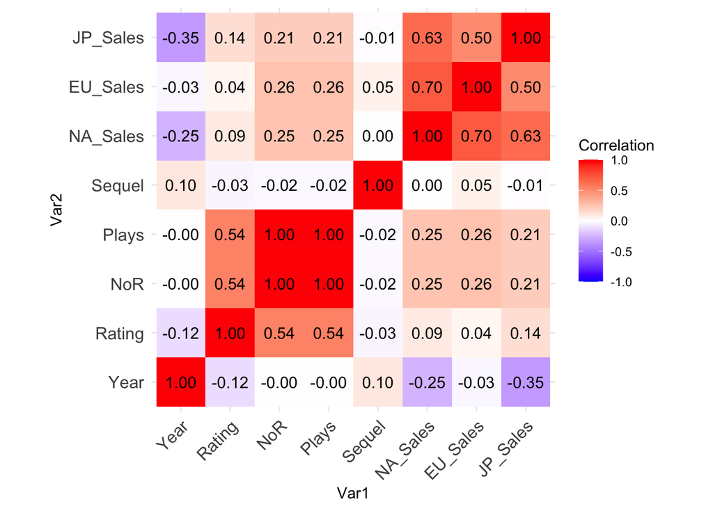

```r
selected_data <- train_data[, c("Year", "Rating", "NoR", "Plays", "Sequel", "NA_Sales","EU_Sales","JP_Sales")]
cor_matrix <- cor(selected_data, use = "complete.obs")

cor_df <- melt(cor_matrix)


ggplot(cor_df, aes(x = Var1, y = Var2, fill = value)) +
  geom_tile() +
  scale_fill_gradient2(low = "blue", high = "red", mid = "white",
                       midpoint = 0, limit = c(-1,1), space = "Lab",
                       name="Correlation") +
  geom_text(aes(label = sprintf("%.2f", value)), size = 4, color = "black") +
  theme_minimal() +
  theme(axis.text.x = element_text(angle = 45, vjust = 1,
                                   size = 12, hjust = 1),
        axis.text.y = element_text(size = 12)) +
  coord_fixed()
```

```r
print(cor_matrix)
```

```
##                  Year      Rating          NoR        Plays       Sequel
## Year      1.000000000 -0.11650673 -0.002218042 -0.002218042  0.101944372
## Rating   -0.116506732  1.00000000  0.537588255  0.537588255 -0.032668322
## NoR      -0.002218042  0.53758826  1.000000000  1.000000000 -0.022407799
## Plays    -0.002218042  0.53758826  1.000000000  1.000000000 -0.022407799
## Sequel    0.101944372 -0.03266832 -0.022407799 -0.022407799  1.000000000
## NA_Sales -0.254941831  0.08695223  0.253227968  0.253227968  0.003596653
## EU_Sales -0.027499693  0.03709585  0.258317123  0.258317123  0.054966144
## JP_Sales -0.345887046  0.13806741  0.214481833  0.214481833 -0.006880462
##              NA_Sales    EU_Sales     JP_Sales
## Year     -0.254941831 -0.02749969 -0.345887046
## Rating    0.086952232  0.03709585  0.138067406
## NoR       0.253227968  0.25831712  0.214481833
## Plays     0.253227968  0.25831712  0.214481833
## Sequel    0.003596653  0.05496614 -0.006880462
## NA_Sales  1.000000000  0.70350721  0.631687316
## EU_Sales  0.703507212  1.00000000  0.500346428
## JP_Sales  0.631687316  0.50034643  1.000000000
```

```r
control <- trainControl(method = "cv", number = 10)
set.seed(123)
lm_model1 <- train(Global_Sales ~ Year + Rating + NoR +  Genre+ Platform_Category + Sequel + NA_Sales,
                   data = train_data,
                   method = "lm",
                   trControl = control)

lm_model2 <- train(Global_Sales ~Year + Rating + NoR  + Genre + Platform_Category + Sequel + JP_Sales,
                   data = train_data,
                   method = "lm",
                   trControl = control)

lm_model3 <- train(Global_Sales ~ Year + Rating + NoR  + Genre + Platform_Category + Sequel + EU_Sales,
                   data = train_data,
                   method = "lm",
                   trControl = control)


summary(lm_model1)
```

```
##
## Call:
## lm(formula = .outcome ~ ., data = dat)
##
## Residuals:
##     Min      1Q  Median      3Q     Max
## -8.8077 -0.4349 -0.1466  0.2267 10.4520
##
## Coefficients:
##                               Estimate   Std. Error t value
## (Intercept)               -47.23085999  15.65471694  -3.017
## Year                        0.02355266   0.00776304   3.034
## Rating                     -0.15357093   0.10352469  -1.483
## NoR                         0.00041150   0.00009585   4.293
## GenreAdventure             -0.18568041   0.17966455  -1.033
## GenreFighting               0.04027541   0.23004613   0.175
## GenreMisc                  -0.25146282   0.25316850  -0.993
## GenrePlatform              -0.00369935   0.14968022  -0.025
## GenrePuzzle                -0.74517168   0.35883255  -2.077
## GenreRacing                 1.05194633   0.26691256   3.941
## `GenreRole-Playing`         0.09825105   0.13099231   0.750
## GenreShooter               -0.17722951   0.12899407  -1.374
## GenreSimulation             1.46629440   0.42688138   3.435
## GenreSports                 0.22801082   0.28274557   0.806
## GenreStrategy               0.03092470   0.32209851   0.096
## Platform_CategoryNintendo   0.53229786   0.13256911   4.015
## Platform_CategoryOthers     0.48003205   0.14448761   3.322
## Platform_CategorySony       0.62286548   0.11668453   5.338
## Sequel                      0.17761829   0.09063925   1.960
## NA_Sales                    1.68219243   0.02188676  76.859
##                                       Pr(>|t|)
## (Intercept)                           0.002647 **
## Year                                  0.002505 **
## Rating                                0.138423
## NoR                                0.000020169 ***
## GenreAdventure                        0.301743
## GenreFighting                         0.861072
## GenreMisc                             0.320934
## GenrePlatform                         0.980289
## GenrePuzzle                           0.038207 *
## GenreRacing                        0.000089436 ***
## `GenreRole-Playing`                   0.453482
## GenreShooter                          0.169913
## GenreSimulation                       0.000629 ***
## GenreSports                           0.420283
## GenreStrategy                         0.923541
## Platform_CategoryNintendo          0.000065964 ***
## Platform_CategoryOthers               0.000940 ***
## Platform_CategorySony              0.000000128 ***
## Sequel                                0.050447 .
## NA_Sales                  < 0.0000000000000002 ***
## ---
## Signif. codes:  0 '***' 0.001 '**' 0.01 '*' 0.05 '.' 0.1 ' ' 1
##
## Residual standard error: 1.106 on 683 degrees of freedom
## Multiple R-squared:  0.9192, Adjusted R-squared:  0.917
## F-statistic:   409 on 19 and 683 DF,  p-value: < 0.00000000000000022
```

```r
summary(lm_model2)
```

```
##
## Call:
## lm(formula = .outcome ~ ., data = dat)
##
## Residuals:
##     Min      1Q  Median      3Q     Max
## -7.0797 -1.0829 -0.3173  0.6928 17.5812
##
## Coefficients:
##                             Estimate Std. Error t value             Pr(>|t|)
## (Intercept)               30.2753874 34.4623296   0.879             0.379978
## Year                      -0.0136995  0.0170995  -0.801             0.423316
## Rating                    -0.4867451  0.2271813  -2.143             0.032503
## NoR                        0.0012642  0.0002077   6.088       0.000000001912
## GenreAdventure            -1.0364446  0.3947190  -2.626             0.008839
## GenreFighting             -0.1751980  0.5065131  -0.346             0.729532
## GenreMisc                  0.3431485  0.5562999   0.617             0.537545
## GenrePlatform              0.1246084  0.3291852   0.379             0.705150
## GenrePuzzle                1.8746050  0.7818055   2.398             0.016762
## GenreRacing                2.2189521  0.5850337   3.793             0.000162
## `GenreRole-Playing`       -1.2306345  0.2912955  -4.225       0.000027173466
## GenreShooter               0.8413380  0.2823674   2.980             0.002989
## GenreSimulation           -2.3929590  0.9539640  -2.508             0.012357
## GenreSports                0.3588372  0.6216847   0.577             0.563994
## GenreStrategy              0.2163159  0.7082011   0.305             0.760121
## Platform_CategoryNintendo -1.8802674  0.2955269  -6.362       0.000000000364
## Platform_CategoryOthers   -1.7196531  0.3105450  -5.538       0.000000043788
## Platform_CategorySony     -0.6721662  0.2558680  -2.627             0.008807
## Sequel                     0.4090199  0.1990521   2.055             0.040275
## JP_Sales                   4.1602407  0.1595232  26.079 < 0.0000000000000002
##
## (Intercept)
## Year
## Rating                    *
## NoR                       ***
## GenreAdventure            **
## GenreFighting
## GenreMisc
## GenrePlatform
## GenrePuzzle               *
## GenreRacing               ***
## `GenreRole-Playing`       ***
## GenreShooter              **
## GenreSimulation           *
## GenreSports
## GenreStrategy
## Platform_CategoryNintendo ***
## Platform_CategoryOthers   ***
## Platform_CategorySony     **
## Sequel                    *
## JP_Sales                  ***
## ---
## Signif. codes:  0 '***' 0.001 '**' 0.01 '*' 0.05 '.' 0.1 ' ' 1
##
## Residual standard error: 2.432 on 683 degrees of freedom
## Multiple R-squared:  0.6094, Adjusted R-squared:  0.5986
## F-statistic: 56.09 on 19 and 683 DF,  p-value: < 0.00000000000000022
```

```r
summary(lm_model3)
```

```
##
## Call:
## lm(formula = .outcome ~ ., data = dat)
##
## Residuals:
##      Min       1Q   Median       3Q      Max
## -11.3732  -0.5648  -0.0297   0.3978  26.3744
##
## Coefficients:
##                              Estimate  Std. Error t value             Pr(>|t|)
## (Intercept)               228.9273834  24.6707378   9.279 < 0.0000000000000002
## Year                       -0.1138837   0.0122377  -9.306 < 0.0000000000000002
## Rating                     -0.0478154   0.1695494  -0.282             0.778018
## NoR                         0.0005514   0.0001572   3.508             0.000482
## GenreAdventure              0.1005289   0.2940031   0.342             0.732508
## GenreFighting               0.2871375   0.3756861   0.764             0.444952
## GenreMisc                   0.5601581   0.4133016   1.355             0.175762
## GenrePlatform               0.1727540   0.2443916   0.707             0.479886
## GenrePuzzle                 2.2522074   0.5795220   3.886             0.000112
## GenreRacing                -0.0741548   0.4430475  -0.167             0.867125
## `GenreRole-Playing`         0.2256651   0.2140854   1.054             0.292215
## GenreShooter                0.1510269   0.2102785   0.718             0.472865
## GenreSimulation             0.4467692   0.6983109   0.640             0.522527
## GenreSports                -0.2522547   0.4623219  -0.546             0.585501
## GenreStrategy              -0.1088709   0.5262399  -0.207             0.836162
## Platform_CategoryNintendo  -0.0522848   0.2157928  -0.242             0.808627
## Platform_CategoryOthers    -1.0360646   0.2315311  -4.475           0.00000896
## Platform_CategorySony      -0.2899684   0.1897209  -1.528             0.126878
## Sequel                      0.0999673   0.1483057   0.674             0.500500
## EU_Sales                    2.8539506   0.0675235  42.266 < 0.0000000000000002
##
## (Intercept)               ***
## Year                      ***
## Rating
## NoR                       ***
## GenreAdventure
## GenreFighting
## GenreMisc
## GenrePlatform
## GenrePuzzle               ***
## GenreRacing
## `GenreRole-Playing`
## GenreShooter
## GenreSimulation
## GenreSports
## GenreStrategy
## Platform_CategoryNintendo
## Platform_CategoryOthers   ***
## Platform_CategorySony
## Sequel
## EU_Sales                  ***
## ---
## Signif. codes:  0 '***' 0.001 '**' 0.01 '*' 0.05 '.' 0.1 ' ' 1
##
## Residual standard error: 1.807 on 683 degrees of freedom
## Multiple R-squared:  0.7844, Adjusted R-squared:  0.7784
## F-statistic: 130.8 on 19 and 683 DF,  p-value: < 0.00000000000000022
```

```r
print(lm_model1$results)
```

```
##   intercept     RMSE  Rsquared       MAE   RMSESD RsquaredSD     MAESD
## 1      TRUE 1.194379 0.9289921 0.6132143 0.610244 0.03413338 0.1303387
```

```r
print(lm_model2$results)
```

```
##   intercept     RMSE Rsquared      MAE    RMSESD RsquaredSD     MAESD
## 1      TRUE 2.404024 0.571405 1.512135 0.7116846  0.1677307 0.2456405
```

```r
print(lm_model3$results)
```

```
##   intercept     RMSE  Rsquared       MAE    RMSESD RsquaredSD     MAESD
## 1      TRUE 1.684851 0.7727067 0.8271092 0.8930215  0.2104927 0.1472549
```

```r
control <- trainControl(method = "cv", number = 10)
set.seed(123)
lm_model1 <- train(Global_Sales ~ Year + Rating + NoR  + Genre + Platform_Category + Sequel +NA_Sales,
                   data = train_data,
                   method = "lm",
                   trControl = control)

lm_model2 <- train(Global_Sales ~Year + Rating + NoR  + Genre + Platform_Category + Sequel + JP_Sales,
                   data = train_data,
                   method = "lm",
                   trControl = control)

lm_model3 <- train(Global_Sales ~ Year + Rating + NoR  + Genre + Platform_Category + Sequel + EU_Sales,
                   data = train_data,
                   method = "lm",
                   trControl = control)


summary(lm_model1)
```

```
##
## Call:
## lm(formula = .outcome ~ ., data = dat)
##
## Residuals:
##     Min      1Q  Median      3Q     Max
## -8.8077 -0.4349 -0.1466  0.2267 10.4520
##
## Coefficients:
##                               Estimate   Std. Error t value
## (Intercept)               -47.23085999  15.65471694  -3.017
## Year                        0.02355266   0.00776304   3.034
## Rating                     -0.15357093   0.10352469  -1.483
## NoR                         0.00041150   0.00009585   4.293
## GenreAdventure             -0.18568041   0.17966455  -1.033
## GenreFighting               0.04027541   0.23004613   0.175
## GenreMisc                  -0.25146282   0.25316850  -0.993
## GenrePlatform              -0.00369935   0.14968022  -0.025
## GenrePuzzle                -0.74517168   0.35883255  -2.077
## GenreRacing                 1.05194633   0.26691256   3.941
## `GenreRole-Playing`         0.09825105   0.13099231   0.750
## GenreShooter               -0.17722951   0.12899407  -1.374
## GenreSimulation             1.46629440   0.42688138   3.435
## GenreSports                 0.22801082   0.28274557   0.806
## GenreStrategy               0.03092470   0.32209851   0.096
## Platform_CategoryNintendo   0.53229786   0.13256911   4.015
## Platform_CategoryOthers     0.48003205   0.14448761   3.322
## Platform_CategorySony       0.62286548   0.11668453   5.338
## Sequel                      0.17761829   0.09063925   1.960
## NA_Sales                    1.68219243   0.02188676  76.859
##                                       Pr(>|t|)
## (Intercept)                           0.002647 **
## Year                                  0.002505 **
## Rating                                0.138423
## NoR                                0.000020169 ***
## GenreAdventure                        0.301743
## GenreFighting                         0.861072
## GenreMisc                             0.320934
## GenrePlatform                         0.980289
## GenrePuzzle                           0.038207 *
## GenreRacing                        0.000089436 ***
## `GenreRole-Playing`                   0.453482
## GenreShooter                          0.169913
## GenreSimulation                       0.000629 ***
## GenreSports                           0.420283
## GenreStrategy                         0.923541
## Platform_CategoryNintendo          0.000065964 ***
## Platform_CategoryOthers               0.000940 ***
## Platform_CategorySony              0.000000128 ***
## Sequel                                0.050447 .
## NA_Sales                  < 0.0000000000000002 ***
## ---
## Signif. codes:  0 '***' 0.001 '**' 0.01 '*' 0.05 '.' 0.1 ' ' 1
##
## Residual standard error: 1.106 on 683 degrees of freedom
## Multiple R-squared:  0.9192, Adjusted R-squared:  0.917
## F-statistic:   409 on 19 and 683 DF,  p-value: < 0.00000000000000022
```

```r
summary(lm_model2)
```

```
##
## Call:
## lm(formula = .outcome ~ ., data = dat)
##
## Residuals:
##     Min      1Q  Median      3Q     Max
## -7.0797 -1.0829 -0.3173  0.6928 17.5812
##
## Coefficients:
##                             Estimate Std. Error t value             Pr(>|t|)
## (Intercept)               30.2753874 34.4623296   0.879             0.379978
## Year                      -0.0136995  0.0170995  -0.801             0.423316
## Rating                    -0.4867451  0.2271813  -2.143             0.032503
## NoR                        0.0012642  0.0002077   6.088       0.000000001912
## GenreAdventure            -1.0364446  0.3947190  -2.626             0.008839
## GenreFighting             -0.1751980  0.5065131  -0.346             0.729532
## GenreMisc                  0.3431485  0.5562999   0.617             0.537545
## GenrePlatform              0.1246084  0.3291852   0.379             0.705150
## GenrePuzzle                1.8746050  0.7818055   2.398             0.016762
## GenreRacing                2.2189521  0.5850337   3.793             0.000162
## `GenreRole-Playing`       -1.2306345  0.2912955  -4.225       0.000027173466
## GenreShooter               0.8413380  0.2823674   2.980             0.002989
## GenreSimulation           -2.3929590  0.9539640  -2.508             0.012357
## GenreSports                0.3588372  0.6216847   0.577             0.563994
## GenreStrategy              0.2163159  0.7082011   0.305             0.760121
## Platform_CategoryNintendo -1.8802674  0.2955269  -6.362       0.000000000364
## Platform_CategoryOthers   -1.7196531  0.3105450  -5.538       0.000000043788
## Platform_CategorySony     -0.6721662  0.2558680  -2.627             0.008807
## Sequel                     0.4090199  0.1990521   2.055             0.040275
## JP_Sales                   4.1602407  0.1595232  26.079 < 0.0000000000000002
##
## (Intercept)
## Year
## Rating                    *
## NoR                       ***
## GenreAdventure            **
## GenreFighting
## GenreMisc
## GenrePlatform
## GenrePuzzle               *
## GenreRacing               ***
## `GenreRole-Playing`       ***
## GenreShooter              **
## GenreSimulation           *
## GenreSports
## GenreStrategy
## Platform_CategoryNintendo ***
## Platform_CategoryOthers   ***
## Platform_CategorySony     **
## Sequel                    *
## JP_Sales                  ***
## ---
## Signif. codes:  0 '***' 0.001 '**' 0.01 '*' 0.05 '.' 0.1 ' ' 1
##
## Residual standard error: 2.432 on 683 degrees of freedom
## Multiple R-squared:  0.6094, Adjusted R-squared:  0.5986
## F-statistic: 56.09 on 19 and 683 DF,  p-value: < 0.00000000000000022
```

```r
summary(lm_model3)
```

```
##
## Call:
## lm(formula = .outcome ~ ., data = dat)
##
## Residuals:
##      Min       1Q   Median       3Q      Max
## -11.3732  -0.5648  -0.0297   0.3978  26.3744
##
## Coefficients:
##                              Estimate  Std. Error t value             Pr(>|t|)
## (Intercept)               228.9273834  24.6707378   9.279 < 0.0000000000000002
## Year                       -0.1138837   0.0122377  -9.306 < 0.0000000000000002
## Rating                     -0.0478154   0.1695494  -0.282             0.778018
## NoR                         0.0005514   0.0001572   3.508             0.000482
## GenreAdventure              0.1005289   0.2940031   0.342             0.732508
## GenreFighting               0.2871375   0.3756861   0.764             0.444952
## GenreMisc                   0.5601581   0.4133016   1.355             0.175762
## GenrePlatform               0.1727540   0.2443916   0.707             0.479886
## GenrePuzzle                 2.2522074   0.5795220   3.886             0.000112
## GenreRacing                -0.0741548   0.4430475  -0.167             0.867125
## `GenreRole-Playing`         0.2256651   0.2140854   1.054             0.292215
## GenreShooter                0.1510269   0.2102785   0.718             0.472865
## GenreSimulation             0.4467692   0.6983109   0.640             0.522527
## GenreSports                -0.2522547   0.4623219  -0.546             0.585501
## GenreStrategy              -0.1088709   0.5262399  -0.207             0.836162
## Platform_CategoryNintendo  -0.0522848   0.2157928  -0.242             0.808627
## Platform_CategoryOthers    -1.0360646   0.2315311  -4.475           0.00000896
## Platform_CategorySony      -0.2899684   0.1897209  -1.528             0.126878
## Sequel                      0.0999673   0.1483057   0.674             0.500500
## EU_Sales                    2.8539506   0.0675235  42.266 < 0.0000000000000002
##
## (Intercept)               ***
## Year                      ***
## Rating
## NoR                       ***
## GenreAdventure
## GenreFighting
## GenreMisc
## GenrePlatform
## GenrePuzzle               ***
## GenreRacing
## `GenreRole-Playing`
## GenreShooter
## GenreSimulation
## GenreSports
## GenreStrategy
## Platform_CategoryNintendo
## Platform_CategoryOthers   ***
## Platform_CategorySony
## Sequel
## EU_Sales                  ***
## ---
## Signif. codes:  0 '***' 0.001 '**' 0.01 '*' 0.05 '.' 0.1 ' ' 1
##
## Residual standard error: 1.807 on 683 degrees of freedom
## Multiple R-squared:  0.7844, Adjusted R-squared:  0.7784
## F-statistic: 130.8 on 19 and 683 DF,  p-value: < 0.00000000000000022
```

```r
print(lm_model1$results)
```

```
##   intercept     RMSE  Rsquared       MAE   RMSESD RsquaredSD     MAESD
## 1      TRUE 1.194379 0.9289921 0.6132143 0.610244 0.03413338 0.1303387
```

```r
print(lm_model2$results)
```

```
##   intercept     RMSE Rsquared      MAE    RMSESD RsquaredSD     MAESD
## 1      TRUE 2.404024 0.571405 1.512135 0.7116846  0.1677307 0.2456405
```

```r
print(lm_model3$results)
```

```
##   intercept     RMSE  Rsquared       MAE    RMSESD RsquaredSD     MAESD
## 1      TRUE 1.684851 0.7727067 0.8271092 0.8930215  0.2104927 0.1472549
```

```r
nn_model1 <- neuralnet(Global_Sales ~ Year + Rating + Sequel + NA_Sales, data = train_data, hidden = c(4,3), linear.output = TRUE)
plot(nn_model1)
```

[output not shown]

```r
lm_predictions1 <- predict(lm_model1, newdata = test_data)
lm_results1 <- postResample(pred = lm_predictions1, obs = test_data$Global_Sales)
print(lm_results1)
```

```
##      RMSE  Rsquared       MAE
## 1.1809499 0.9805134 0.6127256
```

```r
lm_predictions2 <- predict(lm_model2, newdata = test_data)
lm_results2 <- postResample(pred = lm_predictions2, obs = test_data$Global_Sales)
print(lm_results2)
```

```
##      RMSE  Rsquared       MAE
## 4.8788952 0.4410377 1.7382531
```

```r
lm_predictions3 <- predict(lm_model3, newdata = test_data)
lm_results3 <- postResample(pred = lm_predictions3, obs = test_data$Global_Sales)
print(lm_results3)
```

```
##      RMSE  Rsquared       MAE
## 1.1294059 0.9668612 0.7598978
```

```r
predictions_test <- compute(nn_model1, test_data[, c("Year", "Rating", "Sequel","NA_Sales")])
predicted_values <- predictions_test$net.result
mse_val <- mse(test_data$Global_Sales, predicted_values)
rmse_val <- rmse(test_data$Global_Sales, predicted_values)
mae_val <- mae(test_data$Global_Sales, predicted_values)
results <- list(MSE = mse_val, RMSE = rmse_val, MAE = mae_val)
print(results)
```

```
## $MSE
## [1] 37.70083
##
## $RMSE
## [1] 6.1401
##
## $MAE
## [1] 2.2851
```

Q4

```r
Q4data <- Q2data%>%
  mutate(High_Rating = ifelse(Rating >= 4, 1, 0))
set.seed(123)
sample_index <- sample(seq_len(nrow(Q4data)), size = 0.7*nrow(Q4data))
train_data2 <- Q4data[sample_index, ]
test_data2 <- Q4data[-sample_index, ]
```

```r
model_logistic <- glm(High_Rating ~ Year + NoR + Genre + Platform_Category + Sequel + Global_Sales, family = binomial(link='logit'), data = train_data2)


model_tree <- rpart(High_Rating ~ Year + NoR + Genre + Platform_Category + Sequel + Global_Sales, data = train_data2, method = "class")


model_svm <- svm(High_Rating ~ Year + NoR + Genre + Platform_Category + Sequel + Global_Sales, data = train_data2, kernel = "radial", cost = 10, gamma = 0.1)
```

```r
pred_logistic <- predict(model_logistic, newdata = test_data2, type = "response")

pred_logistic_class <- ifelse(pred_logistic > 0.5, 1, 0)

actual_labels <- test_data2$High_Rating
accuracy <- sum(pred_logistic_class == actual_labels) / length(actual_labels)
print(paste("accuracy for logistic:", round(accuracy, 4)))
```

```
## [1] "accuracy for logistic: 0.8256"
```

```r
confusion_matrix_logistic <- table(Actual = actual_labels, Predicted = pred_logistic_class)

df_melted_logistic <- melt(as.data.frame(confusion_matrix_logistic))
```

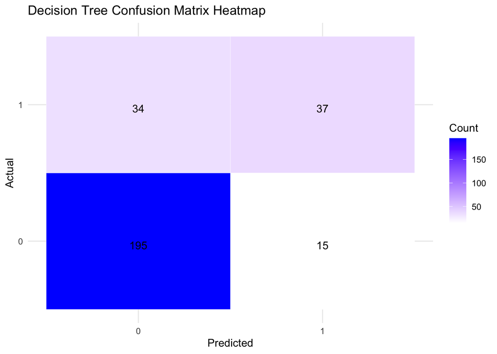

```r
ggplot(data = df_melted_logistic, aes(x = Predicted, y = Actual )) +
  geom_tile(aes(fill = value), color = "white") +
  geom_text(aes(label = sprintf("%d", value)), vjust = 1) +
  scale_fill_gradient(low = "white", high = "blue") +
  theme_minimal() +
 labs(title="Decision Tree Confusion Matrix Heatmap", x="Predicted", y="Actual", fill="Count")
```

```r
pred_tree <- predict(model_tree, newdata = test_data2, type = "class")

actual_labels_tree <- test_data2$High_Rating
accuracy_tree <- sum(pred_tree == actual_labels_tree) / length(actual_labels_tree)
print(paste("accuracy for decision tree:", round(accuracy_tree, 4)))
```

```
## [1] "accuracy for decision tree: 0.8434"
```

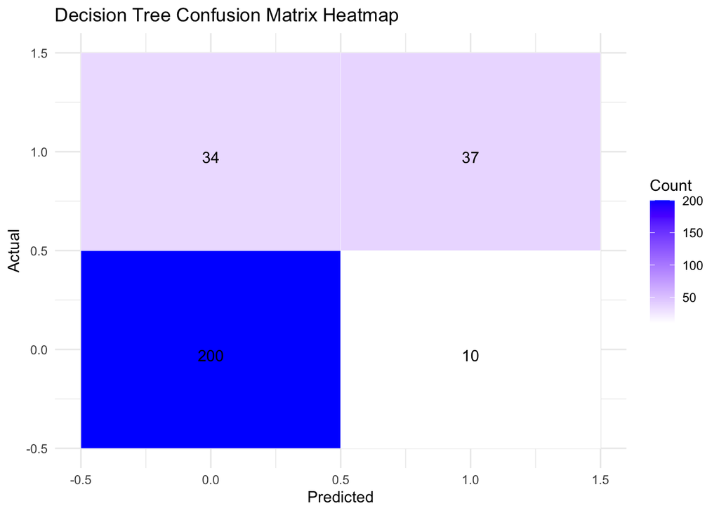

```r
conf_matrix_tree <- table(pred_tree, actual_labels_tree)


conf_matrix_melted_tree <- melt(as.matrix(conf_matrix_tree))

ggplot(data = conf_matrix_melted_tree, aes(x=pred_tree, y=actual_labels_tree)) +
  geom_tile(aes(fill=value), color='white') +
  geom_text(aes(label=sprintf("%d", value)), vjust=1) +
  scale_fill_gradient(low="white", high="blue") +
  theme_minimal() +
  labs(title="Decision Tree Confusion Matrix Heatmap", x="Predicted", y="Actual", fill="Count")
```

```r
pred_svm <- predict(model_svm, newdata = test_data2)
pred_svm_class <- ifelse(pred_svm > 0.5, 1, 0)
actual_labels_svm <- test_data2$High_Rating
accuracy_svm <- sum(pred_svm_class == actual_labels_svm) / length(actual_labels_svm)
print(paste("accuracy for SVM :", round(accuracy_svm, 4)))
```

```
## [1] "accuracy for SVM : 0.8577"
```

```r
confusion_matrix_svm <- table(Actual = actual_labels_svm, Predicted = pred_svm_class)

df_melted_svm <- melt(as.data.frame(confusion_matrix_svm))
```

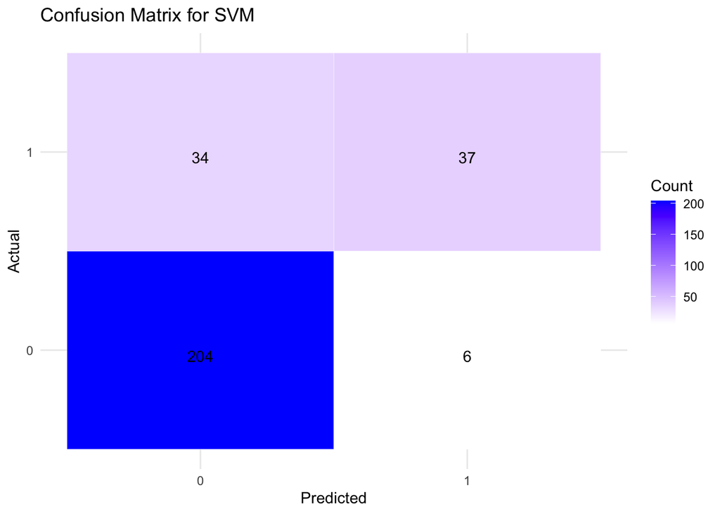

```r
ggplot(data = df_melted_svm, aes(x = Predicted, y = Actual)) +
  geom_tile(aes(fill = value), color = "white") +
  geom_text(aes(label = sprintf("%d", value)), vjust = 1) +
  scale_fill_gradient(low = "white", high = "blue") +
  theme_minimal() +
  labs(title = "Confusion Matrix for SVM",
       x="Predicted", y="Actual", fill="Count")
```

# Summary

## PARAGRAPH 2

To answer the follow-up question, we used three multiple linear regression and neural network techniques to estimate future sales. Our findings suggest that North American sales do play a pivotal role in influencing global game sales. However, the difference between the predictions of North American and European sales is not as large as expected. In addition, to address the interrelationships between certain variables, we used a covariance matrix. It helped us to find that variables such as “Plays” and “NoR” are perfectly linearly correlated (Cor=1). The second problem aimed at predicting whether a game would receive a high rating or not, and we used a variety of methods such as SVM and decision trees. The performance of these models was remarkably similar, with all of them appearing to predict low ratings for games that actually had high ratings. One potential reason for this is that there is a subset of games in our dataset that, despite their high ratings, perform poorly in terms of sales. These questions and their answers are critical for both game developers and gamers. Game companies often aim to get the highest return on investment when strategizing for the next version of a game. This may influence their decisions, such as whether to innovate with new game concepts or continue with a sequel. On the other hand, gamers usually decide whether to buy a game based on past sales figures, game ratings and game genres. These decisions have a direct impact on the game’s sales trajectory and overall ratings. Therefore, understanding these dynamics is crucial to determine the future direction of the gaming industry.